# SDS 237: Final Project

# Introduction

The National Bridge Inventory System (NBIS) dataset documents bridge inspection information and costs associated with bridge replacements of structurally deficient bridges on and off the National Highway System. Data includes identification information, bridge types and specifications, operational conditions, bridge data including geometric data and functional description, and inspection data. This dataset is developed with the purpose of having a unified database for bridges to ensure the safety of the traveling public as required by the Federal-Aid Highway Act of 1968.

## What is the purpose of this guide?

By investigating how various complex systems (e.g., erosion, biology, construction/maintenance chemistry, weather/climate, architecture, U.S. Census and federal highway policy, etc.) interact, we will provide insight into the reasons places dynamically grow, maintain, or lose their infrastructure. We will also explore how the realities of place shape government policy, which will become increasingly important as the climate crisis evolves in the future.

## How was this guide produced?

We first identified a data set that we found to be interesting (NBIS). We then identified stakeholders invested in this data set as well as a target audience for this guide. We settled on BIPOC communities, particularly Indigenous communities as the intended audience. We interviewed a structural bridge engineer in order to better understand the data rituals that go into creating this data set. Finally, we assessed, through a rather extensive literature review, the various discourses surrounding this dataset and our intended audience.

## Who should read this guide?

This guide is intended for Indigenous communities who have been impacted by the number and quality of highways and bridges built on their land.

# User Guide

## Data collection

Bridge engineers are civil engineers who ensure that bridges and roads are structurally sound and will hold up under the weight and stress of loads. Their clients are typically Departments of Transportation (DOT) and their job entails going into the field to assess bridge conditions and report their findings back to their client.

### Definition and categorization of observations

In order to assess and document bridge conditions, bridge engineers break the bridge down into elements and quantify those elements. Each element’s condition is then assessed on a scale of 1-4, where 1 indicates good condition and 4 means some repair is necessary. The bridge as an entire structure is broken up into three main components: (1) deck (what you drive on), superstructure (what holds up the deck), substructure (what holds up the superstructure), and each gets a state-specific rating from 1-10. The inspection is done using several tools: pocket knife, ice pick, hand brace, bit, increment borer for boring timber elements, chipping hammer, binoculars, flashlight, magnifying glass, dye penetrant, mirror, as well as basic measuring and safety equipment.

State Departments of Transportation work with private engineering consultants to develop certain standards for what becomes a certain condition state so as to create a certain quantifiable standard for conditions. It is important to differentiate between structural and aesthetical defects and determine what needs the most attention, given the limited time in the field.

### Data Rituals

In order for the bridge engineers to inspect the bridge, they need to get up close. This sometimes means getting into a crane bucket and being lowered underneath the bridge, to assess things like rust buildup. The engineer might use tools or their hands to touch the bridge to assess its structural integrity, as well as photograph the bridge in order to document its condition. While the engineers are under the bridge, they might try to remove some of the rust using tools to determine the extent of the rust on the bridge. The engineers go into the field with a worksheet, which has a section for each element of the bridge. As they go through the inspection, they document all of their observations on the worksheet. Once the data is collected they give it to their clients and discuss next steps.

## Institutional Stakeholders

**1. The U.S. Department of the Interior** determines the status of historical treaties from federally recognized tribes in the United States. If an indigenous group wants to challenge construction being done on a federal highway on or near their land, they would likely rely on the legal standing of their treaty with the U.S. federal government. The Interior Department would play a major role in determining the status of said treaties, and thus plays a role in data about the US Federal Highway Bridges. The Bureau of Indian Affairs agency (BIA), part of the U.S. Department of the Interior, implements federal laws and policy in Indian Country, including building and maintaining roads and bridges, and so their actions become a part of the Bridges data as well. (SOURCE: https://www.bia.gov/frequently-asked-questions)

**2. The Office of Bridges and Structures** is responsible for the creation and maintenance of the NBI database. They specify that the data are collected in the spring and can be updated throughout the year, but the data are considered final with publication at the end of the calendar year. They require data for all bridges on the National Highway System (NHS), and it is optional for those that are not on the NHS (https://www.fhwa.dot.gov/bridge/nbi/element2020.cfm).

**5. The Massachusetts Depart of Transportation (MassDOT)** acts as “Lead Agency” in interaction with USDOT/FHWA and is responsible for maintaining the inventory of all bridges within the Commonwealth. MassDOT formalizes the inspection of all MassDOT owned bridges by instituting a Bridge Inspection Program, in which they inspect all city and town owned bridges that meet the federal definition of a bridge. The functions of a Bridge Inspection Program includes conducting bridge inspections, reporting the results of inspections, evaluating the results, maintaining a Bridge History File documenting the condition of all bridges in the State, and maintaining an electronic bridge management and inventory database. In order to maintain the above mentioned functions, it is necessary to supervise and coordinate the work of the inspection force, provide training to the inspectors, review their performance, maintain records of inventories, inspections, and bridge rating, report found deficiencies to appropriate authorities, report the safe load carrying capacity for bridges, initiate recommendation to the State Bridge Engineer to reduce load limits or close bridges where necessary.

**6. The Supreme Court of the United States** is the highest court for disputes between groups in the U.S., including disputes over the construction of highways and their bridges. A major case between United States Indigenous groups and the government involved the G-O Road that would have affected Native American sacred sites in Northern California and resulted in the 1988 case of Lyng vs. Northwest Indian Cemetery Protective Association. The Indigenous group lost the case under an act designed to protect sacred sites that had been passed earlier, which means that now Native American groups must rely on laws designed to protect historic sites instead. This decision and future cases will directly affect the data collected about bridges on U.S. Federal highways. (Source: https://sacredland.org/u-s-laws-court-cases-involving-sacred-lands/)

## Impact of popular discourses on data

The NBI data set is in English and metric measurement which can clash with the languages and counting systems of Native American and Alaskan Indians.

Popular discourse has minimized the contributions of Native American and Alaskan Indians, which leads to these groups not being seen as experts and not sought out to contribute to knowledge products like the NBI.

For Native American and Alaskan Indian communities, data sovereignty is an important element of the discourse around datasets that involve indigenous lives. Data sovereignty is “the right of Native nations to govern the collection, ownership, and application of its own data" (Rainie, Rodriguez-Lonebear, & Martinez).[^1] Data sovereignty also encompasses the idea that existing data are “inconsistent, inaccurate, and irrelevant to tribal goals," and collected, owned, and applied by entities outside of tribal governance (Rainie, Rodriguez-Lonebear, & Martinez). These same entities have a history of exploiting Native data. Lastly, the existing lack of infrastructure (e.g., electricity and internet) on Native land makes it difficult for Native communities to address these problems.

The NBI data set includes data that are collected, owned, and applied by the U.S. government. It is also distributed in a way that may make it difficult for Native and Alaskan Indian peoples without necessary existing infrastructure to access and work with. These realities and other discourses around colonization and decolonization of data affect how the NBI data set is recognized and used by BIPOC communities.

## Visualizing the Data

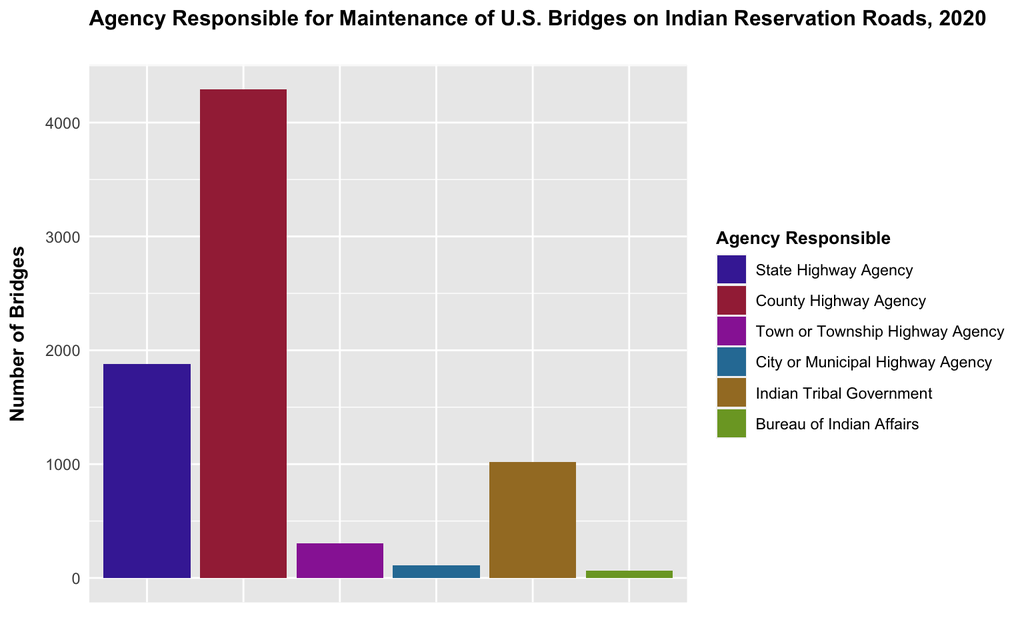

This visualization uses NBI data filtered to only include bridges on Indian Reservation Roads (IRRs).[^2] The visualization includes the six most common organizations responsible for maintenance of bridges on IRRs. From the visualization, it is evident that County Highway Agencies are the most common entity responsible for bridge maintenance on IRRs, followed by State Highway Agencies and and Indian Tribal Governments.

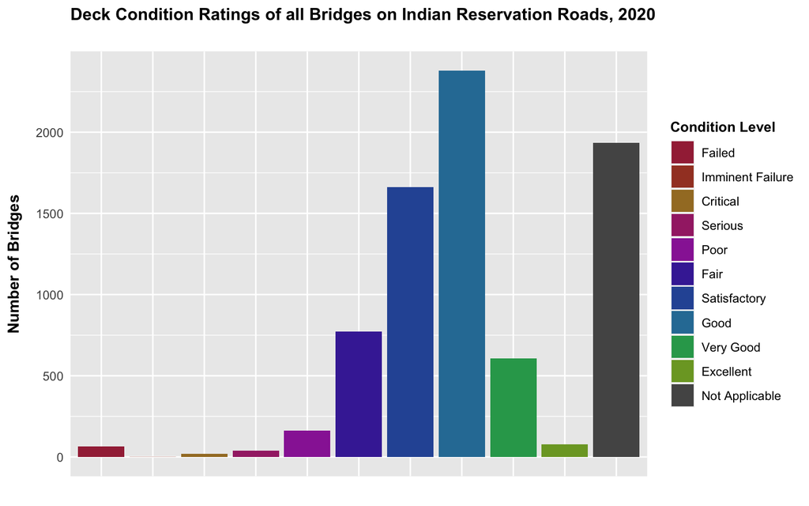

This visualization illustrates the deck condition ratings of all bridges on IRRs. Items 58, 59, and 60 all focus on the condition of bridge components. For specific information about the condition of the superstructure or substructure of a bridge, the data can be filtered to look at items 59 or 60.

[^1]: Rainie, S. C., Rodriguez-Lonebear, D., & Martinez, A. (2019). Indigenous Data Governance: Strategies from United States Native Nations. Data Science Journal, 18(1), 31. DOI: http://doi.org/10.5334/dsj-2019-031.
[^2]: A code of "1" in item 105 indicates the bridge is on an IRR.